# Bayesian mixed models with brms | session 2

Last updated: 2021-04-16

## Outline

- The notorious Bayes Factor
- Families of distributions / models of keystroke data
- Model comparison (leave-one-out cross-validation)
- Summary / reading recommendations

## The notorious Bayes Factor

### chapter 7.6 in Lee & Wagenmakers (2014)

## Bayes Factor

- *p*-values have two possible outcomes:
1. reject the null (i.e. \(p<0.05\))
2. inconclusive (i.e. \(p>0.05\) – go back to start)
- BFs have a continuum of three possible outcomes (Dienes, 2014, 2016; Dienes & Mclatchie, 2018):
1. Reject the null / alternative hypothesis
2. Inconclusive (get more data!)
3. Accept the null / alternative hypothesis

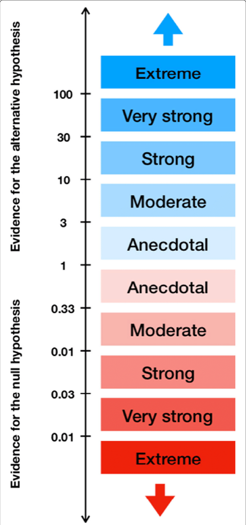

## Bayes Factor

- How much more probable is one model (hypothesis) over the other?
- How convinced should we be about the evidence for our hypothesis \(H_1\) as opposed to, say, a null hypothesis \(H_0\)?
- Savage-Dickey density ratio for “nested models” (Dickey et al., 1970; Jeffreys, 1961).
- Height of the posterior density at zero compared to the height of the prior density at zero.
- **Nested models:**
  - \(H_0\) is nested in \(H_1\) because in \(H_0\) the parameter of interest is fixed (\(\beta=0\)) but is free to vary in \(H_1\) (\(\beta\neq0\))
  - \(H_0\) can be obtained from \(H_1\) by fixing parameter of interest.

## Bayes Factor

- If you care about the alternative hypothesis:

\[ \text{BF} = \frac{p(H_1 \mid y)}{p(H_0 \mid y)} \]

- How much more probable is one model (hypothesis) over the other?
- How convinced should we be about the evidence for our hypothesis as opposed to, say, a null hypothesis?
- Savage-Dickey density ratio for “nested models” (Dickey et al., 1970; Jeffreys, 1961).
- Height of the posterior density at zero compared to the height of the prior density at zero.
- **Nested models:**
- \(H_0\) is nested in \(H_1\) because in \(H_0\) the parameter of interest is fixed (\(\beta=0\)) but is free to vary in \(H_1\) (\(\beta\neq0\))
- \(H_0\) can be obtained from \(H_1\) by fixing parameter of interest.

## Bayes Factor: Savage-Dickey density ratio

\[ \text{BF} = \frac{\text{prior}}{\text{posterior}} \]

- Posterior: \(N(2.5, 1)\)
- Prior: \(N(0,10)\)

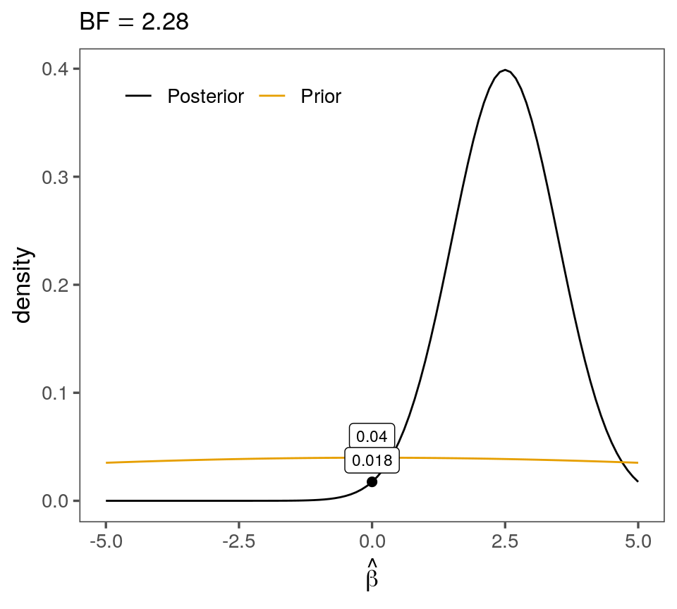

## Bayes Factor: Savage-Dickey density ratio

\[ \text{BF} = \frac{\text{prior}}{\text{posterior}} \]

- Posterior: \(N(2.5, 1)\)
- Prior: \(N(0,5)\)

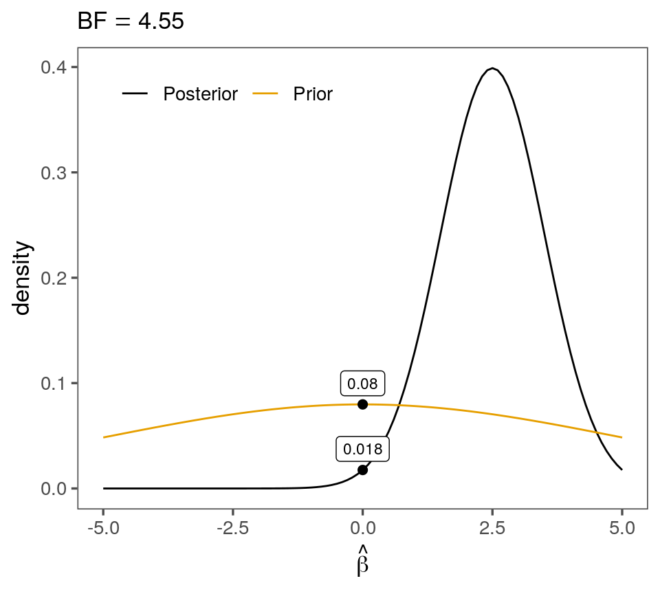

## Bayes Factor: Savage-Dickey density ratio

\[ \text{BF} = \frac{\text{prior}}{\text{posterior}} \]

- Posterior: \(N(2.5, 1)\)
- Prior: \(N(0,2.5)\)

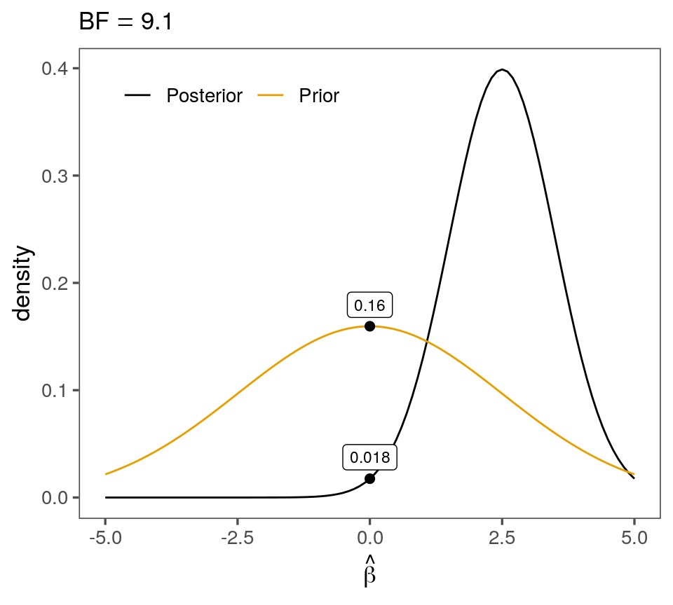

## Bayes Factor: Savage-Dickey density ratio

\[ \text{BF} = \frac{\text{prior}}{\text{posterior}} \]

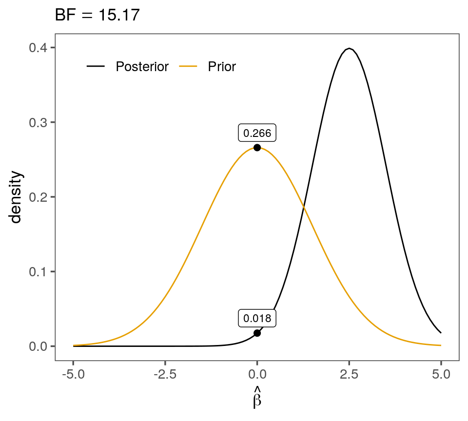

## Bayes Factor

```r
prior <- set_prior("normal(0, 1)", class = "b")
```

```r
fit <- brm(model,
           data = data,
           prior = prior,
           sample_prior = TRUE)
```

- Flat priors are okay (but generally not recommended) defaults if both \(H_0\) and \(H_1\) are plausible.
- More informative priors such as \(N(0,1)\) give more weight to \(H_0\).
- Given such a prior, a posterior that favours \(H_1\) would be more convincing: BFs capture this.
- Regularizing (skeptical) priors prevent the model to get overexcited by the sample (his words: McElreath, 2016).
- `sample_prior = TRUE` to store the priors that that model used.

## Bayes Factor with `hypothesis()`

```r
# Load the model
brms_sim <- readRDS("../stanout/brms_sim_sample_prior.rda")
```

```r
# Test whether the posterior supports H0
hypothesis(brms_sim, "conditionb = 0")
```

```
Hypothesis Tests for class b:
        Hypothesis Estimate Est.Error CI.Lower CI.Upper Evid.Ratio Post.Prob
1 (conditionb) = 0    15.54      8.28    -0.15    31.79       1.97      0.66
  Star
1
---
'CI': 90%-CI for one-sided and 95%-CI for two-sided hypotheses.
'*': For one-sided hypotheses, the posterior probability exceeds 95%;
for two-sided hypotheses, the value tested against lies outside the 95%-CI.
Posterior probabilities of point hypotheses assume equal prior probabilities.
```

- Explore `hypothesis()` in the exercise.

## Exercise: priors and Bayes Factors

- Replace the `---` correctly and run the code.
- Check out how to calculate a BF if you didn’t store the prior: `bayes_factor.R`
- Rerun Bayesian model from last session with `sample_prior = TRUE` and check your the `hypothesis` function: `brms_sim_sample_prior.R`

## Families of distributions

## Families of distributions

> “Models are devices that connect theories to data. A model is an instantiation of a theory […]” (Rouder et al., 2016, p. 2)
- Our models describe how we understand reality.
- Model allows us to describe reality qualitatively (with their parameters) and quantitatively (parameter value estimates, e.g., mean keystroke interval).
- Interpretation of parameters depends on data-modeling context.
- At minimum, distribution families (probability models) depend on data type.
- This isn’t all; there are many distribution families for modeling skewed continuous data.
- Keystroke intervals are skewed even when log scaled: this skew is important!

## Families of distributions (some important ones)

- **Gaussian**: data come from normal distribution (last session)

```r
fit <- brm(outcome ~ predictor + (1|participant), data = data, family = gaussian())
```

## Families of distributions (some important ones)

- **Gaussian**: data come from normal distribution (last session)
- **Bernoulli**: binomial outcomes (yes / no; correct / incorrect)

```r
fit <- brm(outcome ~ predictor + (1|participant), data = data, family = bernoulli())
```

## Families of distributions (some important ones)

- **Gaussian**: data come from normal distribution (last session)
- **Bernoulli**: binomial outcomes (yes / no; correct / incorrect)
- **Poisson**: count data (number of words / mistakes)

```r
fit <- brm(outcome ~ predictor + (1|participant), data = data, family = poisson())
```

## Families of distributions (some important ones)

- **Gaussian**: data come from normal distribution (last session)
- **Bernoulli**: binomial outcomes (yes / no; correct / incorrect)
- **Poisson**: count data (number of words / mistakes)
- **Zero-inflated Poisson**: count data with lots of zeros (number of typos per word)

```r
fit <- brm(outcome ~ predictor + (1|participant), data = data, family = zero_inflated_poisson())
```

## Families of distributions (some important ones)

- **Gaussian**: data come from normal distribution (last session)
- **Bernoulli**: binomial outcomes (yes / no; correct / incorrect)
- **Poisson**: count data (number of words / mistakes)
- **Zero-inflated Poisson**: count data with lots of zeros (number of typos per word)
- Families for ordinal (ordered) data (Bürkner & Vuorre, 2019) (Likert scales)

```r
fit <- brm(outcome ~ predictor + (1|participant), data = data, family = cumulative())# or acat, sratio
```

## Families of distributions (some important ones)

- **Gaussian**: data come from normal distribution (last session)
- **Bernoulli**: binomial outcomes (yes / no; correct / incorrect)
- **Poisson**: count data (number of words / mistakes)
- **Zero-inflated Poisson**: count data with lots of zeros (number of typos per word)
- Families for ordinal (ordered) data (Bürkner & Vuorre, 2019) (Likert scales)
- **Log-Normal**: zero bound data with positive skew; also skewed / shifted (log)-Normal, Wiener Diffusion models etc. [for RT data; Matzke & Wagenmakers (2009)]

```r
fit <- brm(outcome ~ predictor + (1|participant), data = data, family = lognormal())
```

## Families of distributions (some important ones)

- **Gaussian**: data come from normal distribution (last session)
- **Bernoulli**: binomial outcomes (yes / no; correct / incorrect)
- **Poisson**: count data (number of words / mistakes)
- **Zero-inflated Poisson**: count data with lots of zeros (number of typos per word)
- Families for ordinal (ordered) data (Bürkner & Vuorre, 2019) (Likert scales)
- **Log-Normal**: zero bound continuous data with positive skew
- **Ex-Gaussian**: continuous data with positive skew (for key data: Chukharev-Hudilainen, 2014)

```r
fit <- brm(outcome ~ predictor + (1|participant), data = data, family = exgaussian())
```

## Families of distributions (some important ones)

- **Gaussian**: data are assumed to come from a normal distribution (last session)
- **Bernoulli**: binomial data
- **Poisson**: count data
- **Zero-inflated Poisson**: count data with lots of zeros
- Families for ordinal (ordered) data (Bürkner & Vuorre, 2019)
- **Log-Normal**: zero bound continuous data with positive skew
- **Ex-Gaussian**: continuous data with positive skew (for key data: Chukharev-Hudilainen, 2014)
- Mixtures of distributions and distribution families (for key data: Almond et al., 2012; Baaijen et al., 2012; Roeser et al., 2020, 2021)

```r
fit <- brm(outcome ~ predictor + (1|participant), data = data, family = mixture(gaussian(), gaussian()))
```

## Models of keystroke data

- What is a good model of keystroke data?
- For RT data there are many probability models: skewed Normal, shifted (log)-Normal, Wiener Diffusion models, ex-Gaussian etc. (see Matzke & Wagenmakers, 2009).
- Homework: 5 models of keystroke data (intercept only with random ppt intercepts):

## Models of keystroke data

- Keystroke data from 39 participants writing texts in their L1 (English) or L2 (Spanish).
- We will focus on sentence transitions (keystroke interval between sentences) because there is a lot happening before people start a sentence (cite me: Roeser et al., 2019).
- Skew is normal and contains important information.
- Different models entail different ways of thinking about skew.

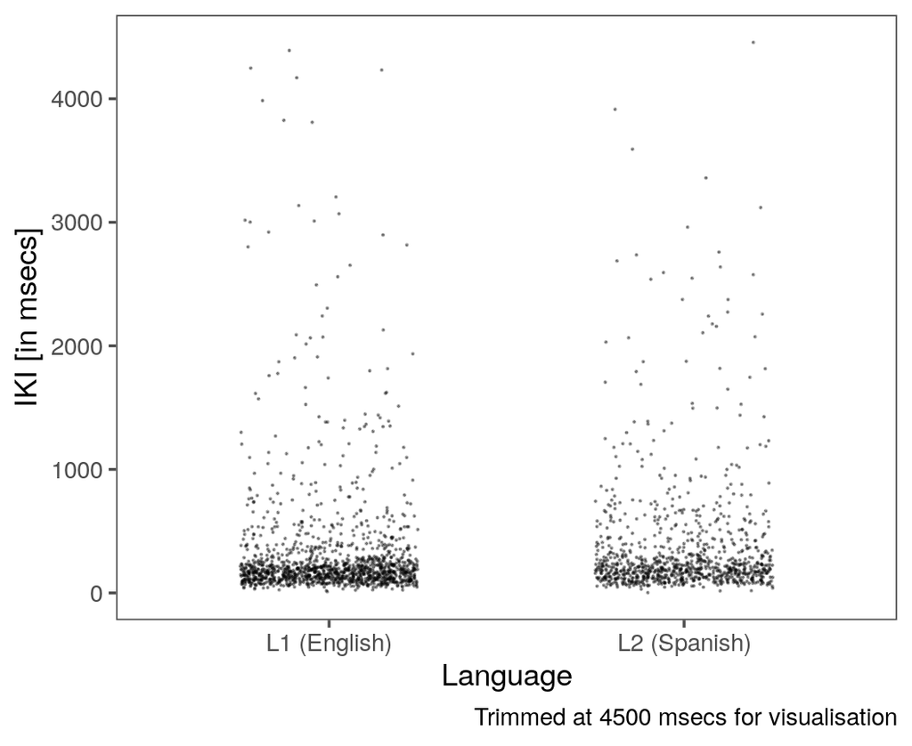

## Gaussian

\[y \sim N(\mu, \sigma^2)\]

- Data generating process can be described as a normal distribution with mean \(\mu\) and standard deviation \(\sigma\).

## Log-Normal

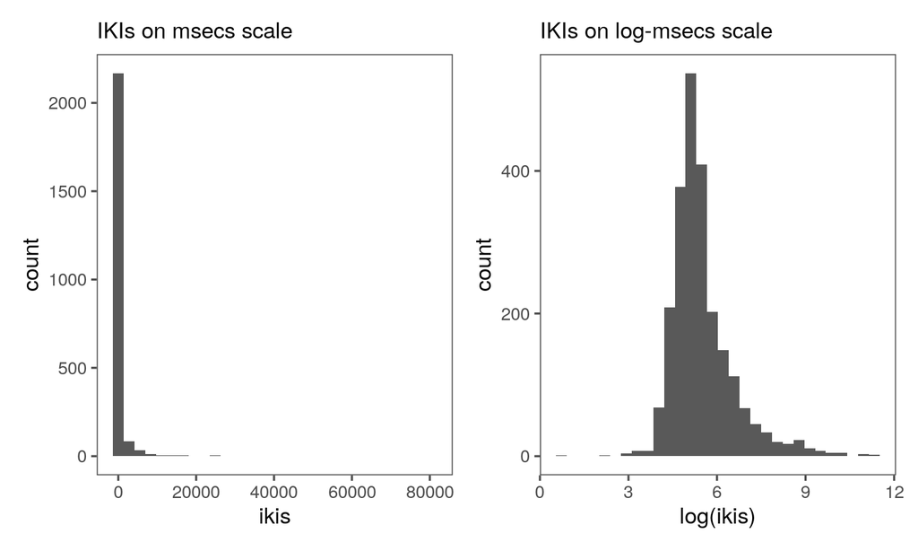

## Log-Normal

\[ y \sim logN(\mu, \sigma^2) \]

- Often used to address positive skew; e.g. response times (Baayen, 2008)
- Log-values are only defined if \(y \in [0, \infty]\)
- De-emphasize large values over small values.
- Models the percentage change and not absolute differences:
  - Rather than saying “keystroke intervals are 40 msecs slower,” you say “keystrokes are 7% slower.”
  - Difference of 40 msecs can be huge for fast typing but negligible for pauses around 10 secs.

## Ex-Gaussian

- Response is caused by a mix of two independent processes:
1. Gaussian distribution
2. Exponential distribution
- Parameters:
  - \(\mu\): mean of the Gaussian; shorter/longer mean keystroke intervals
  - \(\sigma\): standard deviation of the Gaussian; symmetrical variability around \(\mu\)
  - \(\tau\): decay rate of the exponential; the tail of long keystroke intervals (higher \(\tau\) means more tail dominance over the Gaussian)

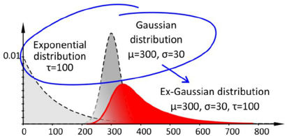

## Ex-Gaussian

[figure not shown]

## Ex-Gaussian

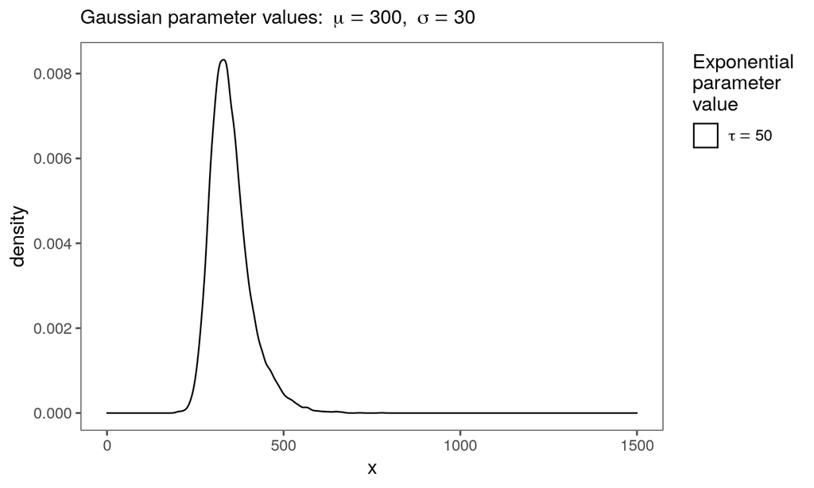

## Ex-Gaussian

[figure not shown]

## Ex-Gaussian

[figure not shown]

## Ex-Gaussian

[figure not shown]

## Ex-Gaussian

```r
model <- bf(IKI ~ 1 + (1 | SubNo),
            beta ~ 1 + (1 | SubNo), # decay parameter (exponential component)
            family = exgaussian())

prior <- set_prior("normal(250, 20)", class = "Intercept") +
         set_prior("normal(6, 2)", class = "Intercept", dpar = "beta") # decay rate in log msecs
```

## Skew-Normal

- Gaussian with extra skew-parameter
- Parameters: mean \(\mu\), standard deviation \(\sigma\)
- Skewness \(\alpha\): Gaussian is \(\alpha = 0\); positive skew \(\alpha > 0\); negative skew \(\alpha < 0\);

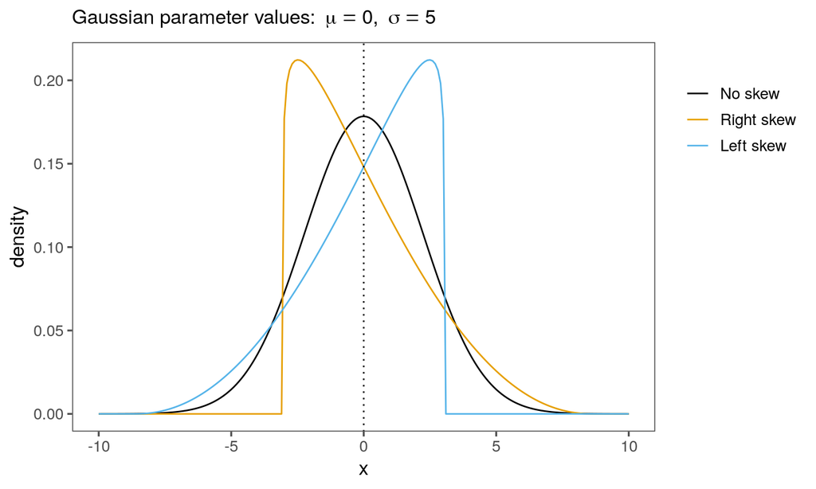

## Mixture model

\[ y \sim \theta \cdot N(\mu_1, \sigma_1) + (1-\theta) \cdot N(\mu_2, \sigma_2) \]

- Finite mixture model with two mixture components with a straight forward interpretation
- Keystroke intervals are a mix of two independent processes (Roeser et al., 2021):
- Short keystroke intervals: e.g. normal planning / execution
- Long keystroke intervals: disfluent execution / planning
- Parameters:
  - \(\mu_1, \sigma_1\): mean and sd of one distribution
  - \(\mu_2, \sigma_2\): mean and sd of other distribution
  - \(\theta\): mixing proportion of distributions
- Mixing proportion \(\theta\) is the probability of *difficulty* in the sample (or condition).

## Mixture model

[figure not shown]

## Mixture model

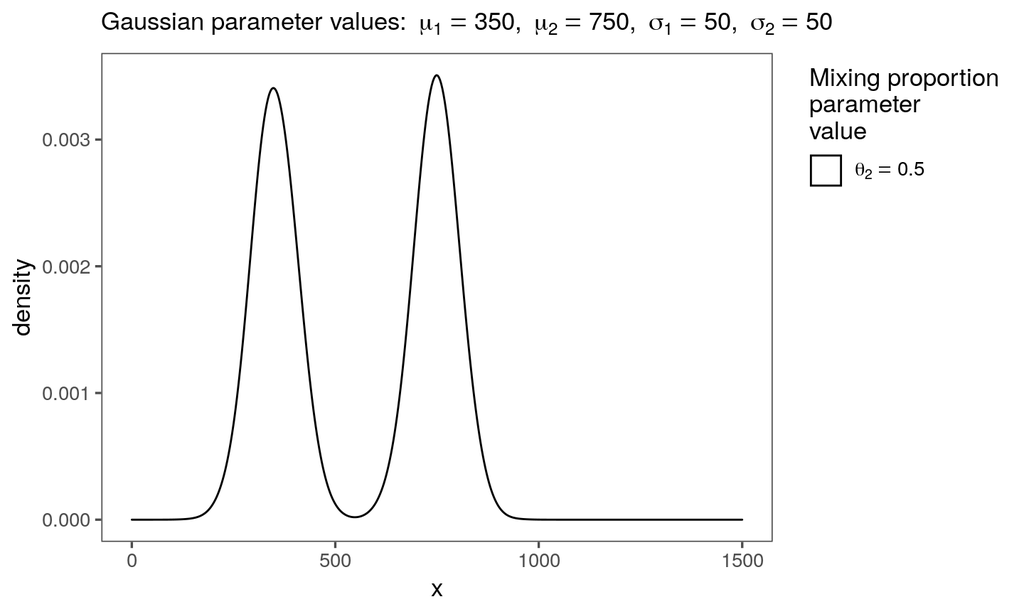

## Mixture model

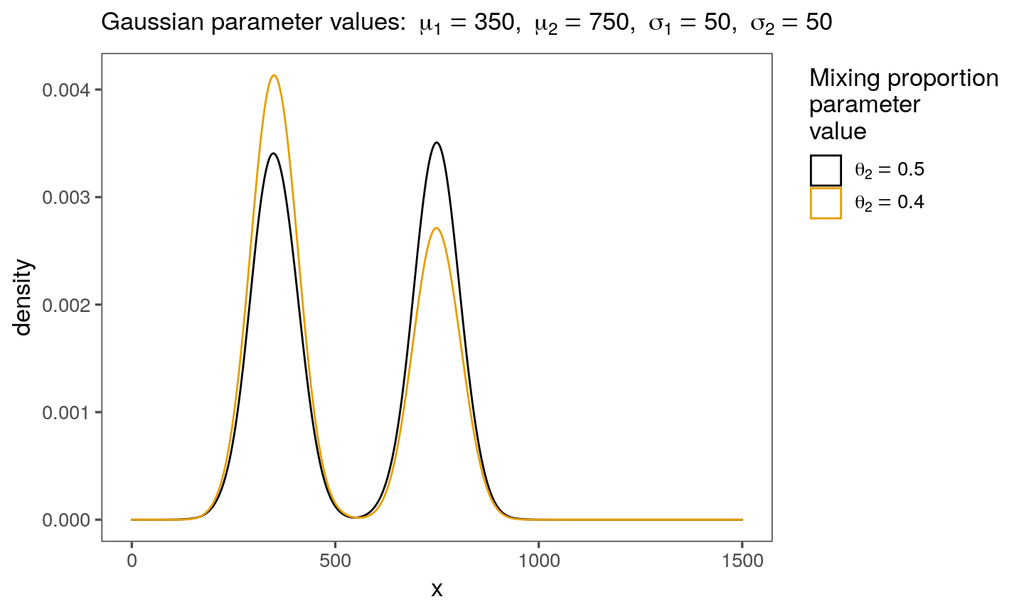

## Mixture model

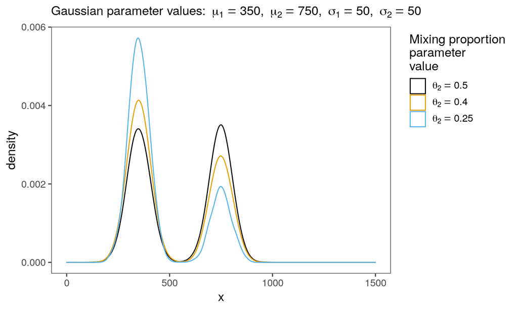

## Mixture model

```r
# Specify mixture model
mixture_of_lognormals <- mixture(lognormal(), lognormal(), order = TRUE)

# Specify model
model <- bf(IKI ~ 1 + (1 | SubNo),
            theta2 ~ 1 + (1 | SubNo),
            family = mixture_of_lognormals)

# Setup priors
prior <-  set_prior("normal(4, 1)", class = "Intercept", dpar = "mu1") +
          set_prior("normal(6, 1)", class = "Intercept", dpar = "mu2") +
          set_prior("beta(2, 2)", class = "Intercept", dpar = "theta2")
```

## Difference between models

| Model | Extreme values |
| --- | --- |
| Gaussian | Values follow normal distribution |
| log-Normal | Re-scale distance between adjacent values |
| skew-Normal | Skewness parameter |
| ex-Gaussian | Exponential component |
| Mixture model | Another (cognitive) process |

## Exercise: model comparison (1)

- How well does the model predict the data?
- Draw data simulations from each model and compare them to the actual data.
- Complete the `---` bits of `visualise_model_fit.R` and run it line-by-line.
- This script assumes that you have stored the posterior of the five models from the homework: Gaussian, log-Normal, skew-Normal, ex-Gaussian, mixture model

## Model predictions

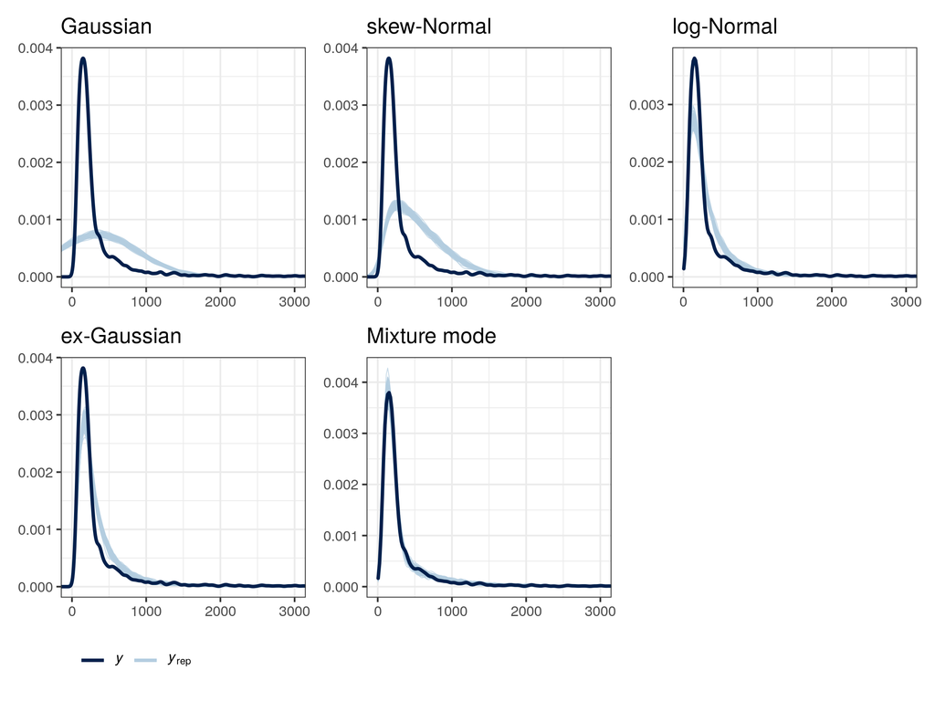

- Observed data \(y\) compared to 100 simulations per model \(y_{rep}\).
- *x*-axis cut off at 0 and 3k.
- Which model does the worst job; which does the best?

## Model comparisons

### chapter 11 in Gelman et al. (2020); chapter 6 in McElreath (2016)

## Model comparisons

- What is a good account of reality for our data (keystroke intervals between sentences)?
- How accurately does the model predict new data.
- \(R^2\) et al.: more complex models are generally better.
- **Overfitting:** models with too many parameters (e.g. predictors) make unreasonable predictions.
- That’s because \(R^2\) is based on the data that were used for model fit.
- Generalisations to data that were used to fit the model are over optimistic (Gelman et al., 2020).
- Instead, evaluating predictive performance of the model for new data.

## Leave-One-Out (LOO) cross validation

- Cross validation: performance of a model on **new** data to remove the overfitting problem.
- Split data into training set (for modelling) and validation set (for prediction).
- Leave-One-Out (LOO) Information Criterion (LOO-IC):
  - Train model on \(N-1\) observations
  - Predict remaining data point from training model.
  - Repeat process \(N\) times to predict every observation from a model of the remaining data.
- Adding up prediction results gives an estimate of **expected log-predictive density** (\(elpd\)); i.e. approximation of results that would be expected for new data.
- This would take forever; `loo()` function uses the probability calculations to approximate LOO-IC (i.e. Pareto smoothed importance sampling) (Vehtari et al., 2015, 2017).

## Leave-One-Out (LOO) cross validation

- Approximation involved in `loo()` uses the log posterior predictive densities: how likely is each data point given the distribution parameter estimates?

## Leave-One-Out (LOO) cross validation

```r
loo(brms_sim)
```

```
Computed from 4000 by 600 log-likelihood matrix

         Estimate   SE
elpd_loo  -3615.4 17.3
p_loo         7.4  0.5
looic      7230.9 34.6
------
Monte Carlo SE of elpd_loo is 0.0.

All Pareto k estimates are good (k < 0.5).
See help('pareto-k-diagnostic') for details.
```

## Leave-One-Out (LOO) cross validation

```r
loo(brms_sim)
```

```
Computed from 4000 by 600 log-likelihood matrix

         Estimate   SE
elpd_loo  -3615.4 17.3
p_loo         7.4  0.5
looic      7230.9 34.6
------
Monte Carlo SE of elpd_loo is 0.0.

All Pareto k estimates are good (k < 0.5).
See help('pareto-k-diagnostic') for details.
```

## Leave-One-Out (LOO) cross validation

```r
loo(brms_sim)
```

```
Computed from 4000 by 600 log-likelihood matrix

         Estimate   SE
elpd_loo  -3615.4 17.3
p_loo         7.4  0.5
looic      7230.9 34.6
------
Monte Carlo SE of elpd_loo is 0.0.

All Pareto k estimates are good (k < 0.5).
See help('pareto-k-diagnostic') for details.
```

- `elpd_loo` and `looic` rarely have a direct interpretation (as opposed to `loo_R2()`): important are differences between models.
- `p_loo` is the effective number of parameters: how flexible is the model fit.

## Model comparison

| model | elpd_diff | se_diff | elpd_loo | se_elpd_loo |
| --- | --- | --- | --- | --- |
| mixturemodel | 0.0 | 0.0 | -13773.6 | 80.7 |
| exgaussian | -626.3 | 56.3 | -14399.9 | 104.1 |
| lognormal | -736.8 | 38.6 | -14510.4 | 81.5 |
| skewnormal | -2125.2 | 95.2 | -15898.8 | 117.2 |
| gaussian | -3270.7 | 104.4 | -17044.3 | 123.4 |

<sup>a</sup> `elpd_loo` is reported as \(\widehat{elpd}\) and the difference as \(\Delta\widehat{elpd}\).

## Mixture-model evaluation

- Summarise the parameter estimates of the mixture model.
- Complete the `---`s in `mixturemodel_posterior.R` and run the script.
- Try to make sense of the parameter estimates.

## Mixture-model parameters (population level)

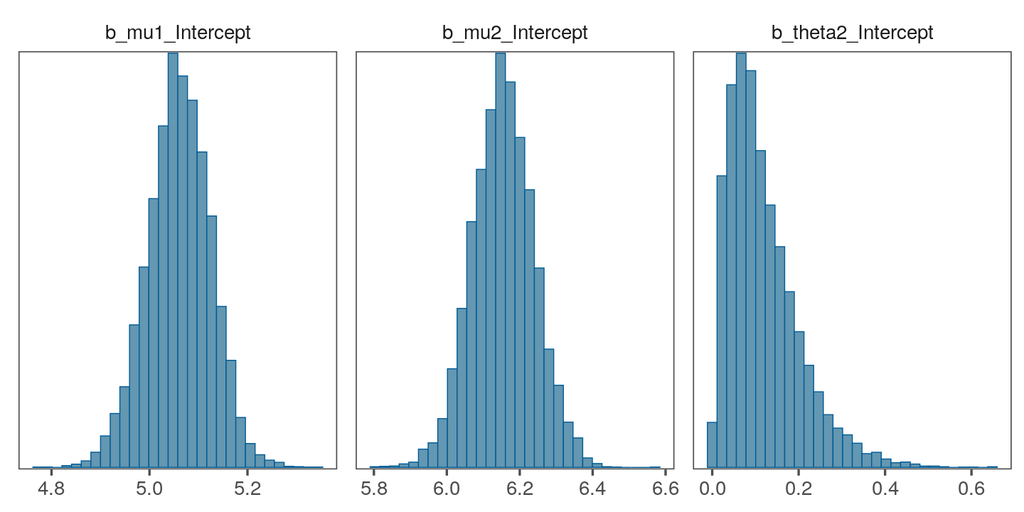

```r
coefs <- c("b_mu1_Intercept", "b_mu2_Intercept", "b_theta2_Intercept")
mcmc_plot(mixturemodel, type = "hist", pars = coefs)
```

## Mixture-model parameters (population level)

```r
posterior_summary(mixturemodel, pars = "b_theta2_Intercept") %>% round(2)
```

```
                   Estimate Est.Error Q2.5 Q97.5
b_theta2_Intercept     0.12      0.08 0.02  0.33
```

```r
coefs <- c("b_mu1_Intercept", "b_mu2_Intercept")

posterior_samples(mixturemodel, pars = coefs) %>%
  pivot_longer(everything()) %>% mutate(value = exp(value)) %>%
  group_by(name) %>% summarise(mean = mean(value),
                               Q2.5 = quantile(value, .025),
                               Q97.5 = quantile(value, .975)) %>%
  mutate(across(where(is.numeric), round, 0))
```

```
# A tibble: 2 x 4
  name             mean  Q2.5 Q97.5
  <chr>           <dbl> <dbl> <dbl>
1 b_mu1_Intercept   158   138   179
2 b_mu2_Intercept   473   400   558
```

## Mixture-model parameters (ppt level)

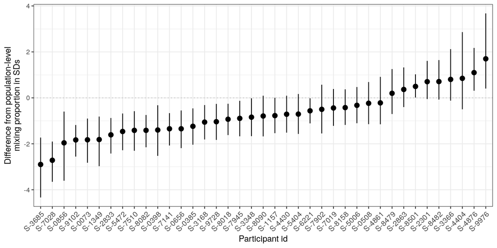

## The end

## Summary

- Priors aid parameter estimation.
- Bayes Factors allow us to compare hypotheses.
- `brms` allows us to fit various models of keystroke intervals:
  - Mixture models showed better fit for sentence transitions.
- Estimate parameter other than expected keystroke latency:
  - Mixing proportion \(\theta_2\) is an indicator of the probability to slow down after accounting for individual typing speed.
- Next: add slope coefficients to compare, e.g., whether L1 affects normal or slow typing or the probability of slowdowns.

## Recommended reading

- Bürkner’s tutorials (Bürkner, 2017, 2018, 2019; Bürkner & Vuorre, 2019)
- Vasishth’s tutorials (Nicenboim & Vasishth, 2016; Sorensen et al., 2016; Vasishth & Nicenboim, 2016)
- Book-length intros: Gelman et al. (2020), McElreath (2016), Kruschke (2014), Lambert (2018), Lee & Wagenmakers (2014)

## References

Almond, R., Deane, P., Quinlan, T., Wagner, M., & Sydorenko, T. (2012). *A preliminary analysis of keystroke log data from a timed writing task* (Research Report No. RR-12-23). Educational Testing Service.

Baaijen, V. M., Galbraith, D., & de Glopper, K. (2012). Keystroke analysis: Reflections on procedures and measures. *Written Communication*, *29*(3), 246–277.

Baayen, R. H. (2008). *Analyzing linguistic data. A practical introduction to statistics using R*. Cambridge University Press.

Bürkner, P.-C. (2017). brms: An R package for Bayesian multilevel models using Stan. *Journal of Statistical Software*, *80*(1), 1–28. https://doi.org/10.18637/jss.v080.i01

Bürkner, P.-C. (2018). Advanced Bayesian multilevel modeling with the R package brms. *The R Journal*, *10*(1), 395–411. https://doi.org/10.32614/RJ-2018-017

Bürkner, P.-C. (2019). Bayesian item response modeling in R with brms and Stan. *arXiv Preprint arXiv:1905.09501*.

Bürkner, P.-C., & Vuorre, M. (2019). Ordinal regression models in psychology: A tutorial. *Advances in Methods and Practices in Psychological Science*, *2*(1), 77–101.

Chukharev-Hudilainen, E. (2014). Pauses in spontaneous written communication: A keystroke logging study. *Journal of Writing Research*, *6*(1), 61–84.

Dickey, J. M., Lientz, B. P., & others. (1970). The weighted likelihood ratio, sharp hypotheses about chances, the order of a markov chain. *The Annals of Mathematical Statistics*, *41*(1), 214–226.

Dienes, Z. (2014). Using Bayes to get the most out of non-significant results. *Frontiers in Psychology*, *5*(781), 1–17.

Dienes, Z. (2016). How Bayes factors change scientific practice. *Journal of Mathematical Psychology*, *72*, 78–89.

Dienes, Z., & Mclatchie, N. (2018). Four reasons to prefer Bayesian analyses over significance testing. *Psychonomic Bulletin & Review*, *25*(1), 207–218.

Gelman, A., Hill, J., & Vehtari, A. (2020). *Regression and other stories*. Cambridge University Press.

Jeffreys, H. (1961). *The theory of probability* (Vol. 3). Oxford University Press, Clarendon Press.

Kruschke, J. K. (2014). *Doing Bayesian data analysis: A tutorial with R, JAGS, and Stan*.

Lambert, B. (2018). *A student’s guide to Bayesian statistics*. Sage.

Lee, M. D., & Wagenmakers, E.-J. (2014). *Bayesian cognitive modeling: A practical course*. Cambridge University Press.

Matzke, D., & Wagenmakers, E.-J. (2009). Psychological interpretation of the ex- Gaussian and shifted Wald parameters: A diffusion model analysis. *Psychonomic Bulletin & Review*, *16*(5), 798–817.

McElreath, R. (2016). *Statistical rethinking: A Bayesian course with examples in R and Stan*. CRC Press.

Nicenboim, B., & Vasishth, S. (2016). Statistical methods for linguistic research: Foundational Ideas – Part II. *Language and Linguistics Compass*, *10*(11), 591–613.

Roeser, J., De Maeyer, S., Leijten, M., & Van Waes, L. (2021). *Modelling typing disfluencies using bayesian mixture models*. https://osf.io/y3p4d/

Roeser, J., Torrance, M., Andrews, M., & Baguley, T. (2020). No scope for planning – language pre-planning as mixture process. *26th Architectures and Mechanisms for Language Processing ( AMLaP)*. https://amlap2020.github.io/

Roeser, J., Torrance, M., & Baguley, T. (2019). Advance planning in written and spoken sentence production. *Journal of Experimental Psychology: Learning, Memory, and Cognition*, *45*(11), 1983–2009.

Rouder, J. N., Morey, R. D., & Wagenmakers, E.-J. (2016). The interplay between subjectivity, statistical practice, and psychological science. *Collabra*, *2*(1), 1–12.

Sorensen, T., Hohenstein, S., & Vasishth, S. (2016). Bayesian linear mixed models using Stan: A tutorial for psychologists, linguists, and cognitive scientists. *Quantitative Methods for Psychology*, *12*(3), 175–200.

Vasishth, S., & Nicenboim, B. (2016). Statistical methods for linguistic research: Foundational ideas – Part I. *arXiv Preprint arXiv:1601.01126*.

Vehtari, A., Gelman, A., & Gabry, J. (2015). Pareto smoothed importance sampling. *arXiv Preprint arXiv:1507.02646*.

Vehtari, A., Gelman, A., & Gabry, J. (2017). Practical bayesian model evaluation using leave-one-out cross-validation and WAIC. *Statistics and Computing*, *27*(5), 1413–1432.